# PA1_template

## 4.- Make a histogram of the total number of steps taken each day and Calculate and report the mean and median total number of steps taken per day. Do these values differ from the estimates from the first part of the assignment? What is the impact of imputing missing data on the estimates of the total daily number of steps?

## BarPlot & Histogram with NA consideration

## Barplot handling NA

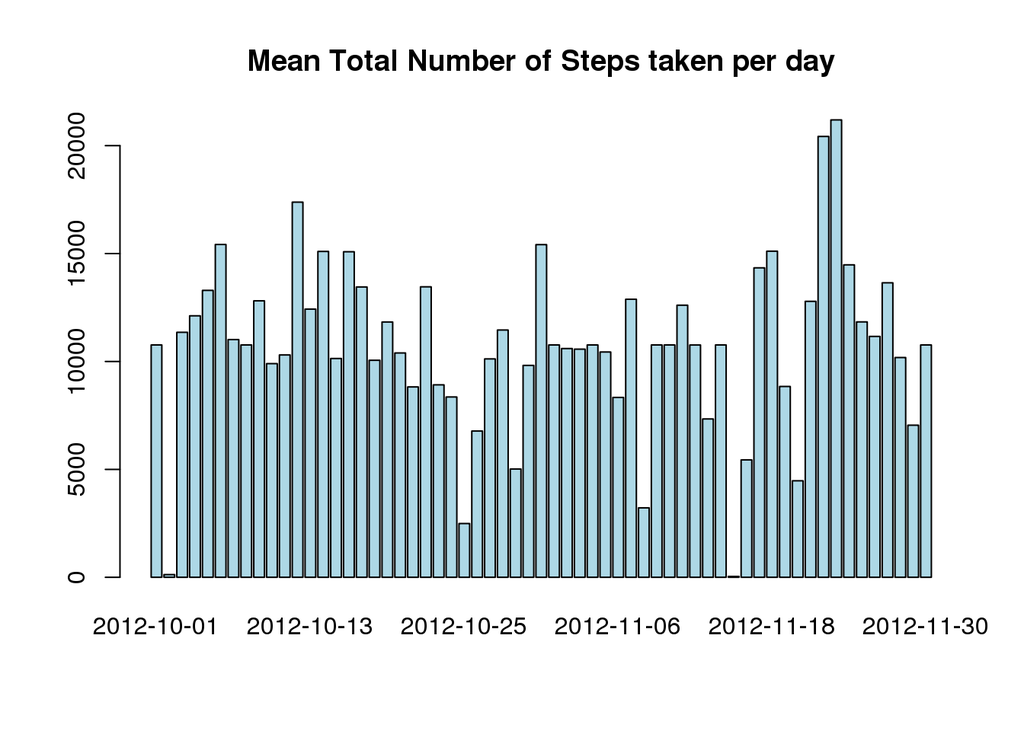

```r
totStepsDays2=lapply(actdf,sum)
barplot(as.numeric(totStepsDays2),names.arg=mydays,main='Mean Total Number of Steps taken per day',col='lightblue')
```

## Histogram handling NA

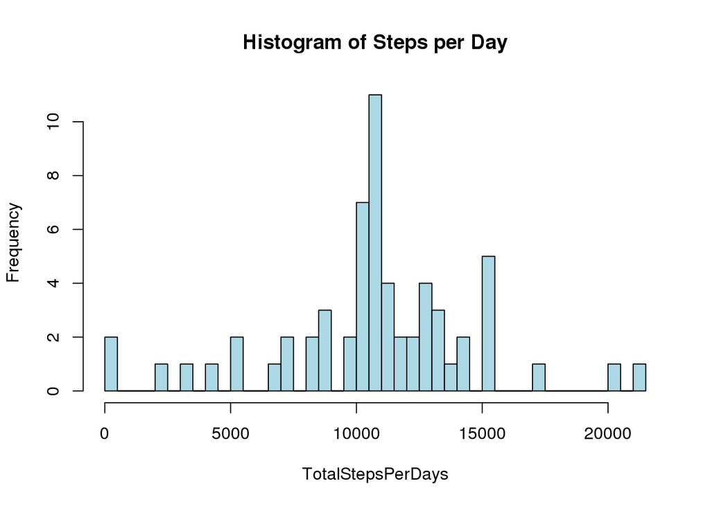

```r
hist(as.numeric(totStepsDays2),breaks=40,col='lightblue',main='Histogram of Steps per Day',xlab='TotalStepsPerDays')
```

## Mean handling NA

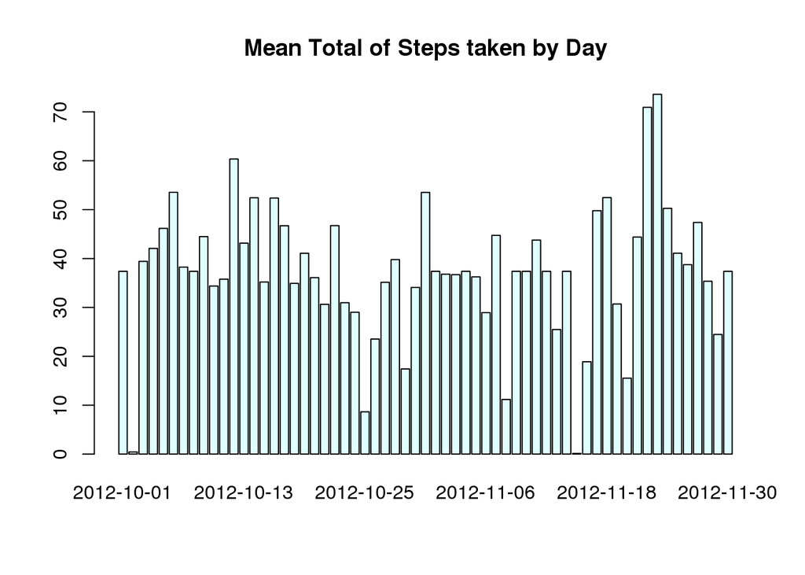

```r
meanStepsDays2=lapply(actdf,mean)
barplot(as.numeric(meanStepsDays2),names.arg=mydays,main='Mean Total of Steps taken by Day',col='lightcyan')
```

## Median handling NA

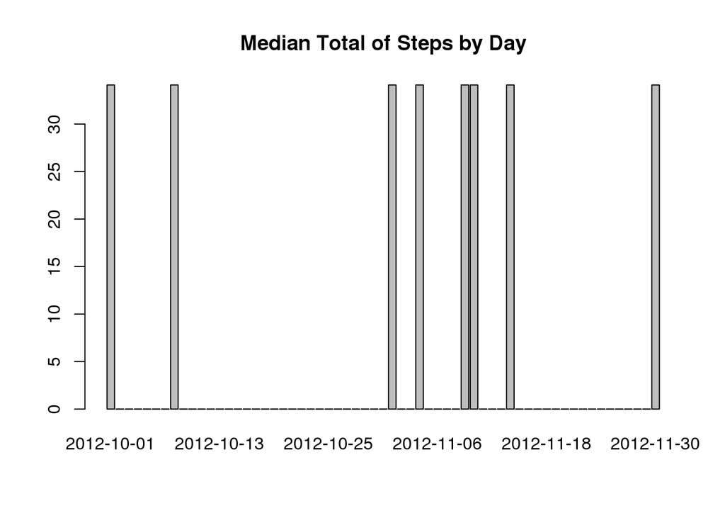

```r
medianStepsDays2=lapply(actdf,median)
barplot(as.numeric(medianStepsDays2),names.arg=mydays,main='Median Total of Steps by Day')
```

## Are there differences in activity patterns between weekdays and weekends?

```r
myday0=substr(colnames(actdf),2,11)
```

## 1. Create a new factor variable in the dataset with two levels – “weekday” and “weekend” indicating whether a given date is a weekday or weekend day.

```r
weekf=weekdays(as.Date(myday0,"%Y.%m.%d"))
for(i in 1:61) if(weekf[i]=="Sunday"||weekf[i]=="Saturday") weekf[i]='weekend' else weekf[i]='weekday'
actdf2=rbind(actdf,weekf)
```

## in my case correspond to a new row

## 2. Make a panel plot containing a time series plot (i.e. type = “l”) of the 5-minute interval (x-axis) and the average number of steps taken, averaged across all weekday days or weekend days (y-axis).

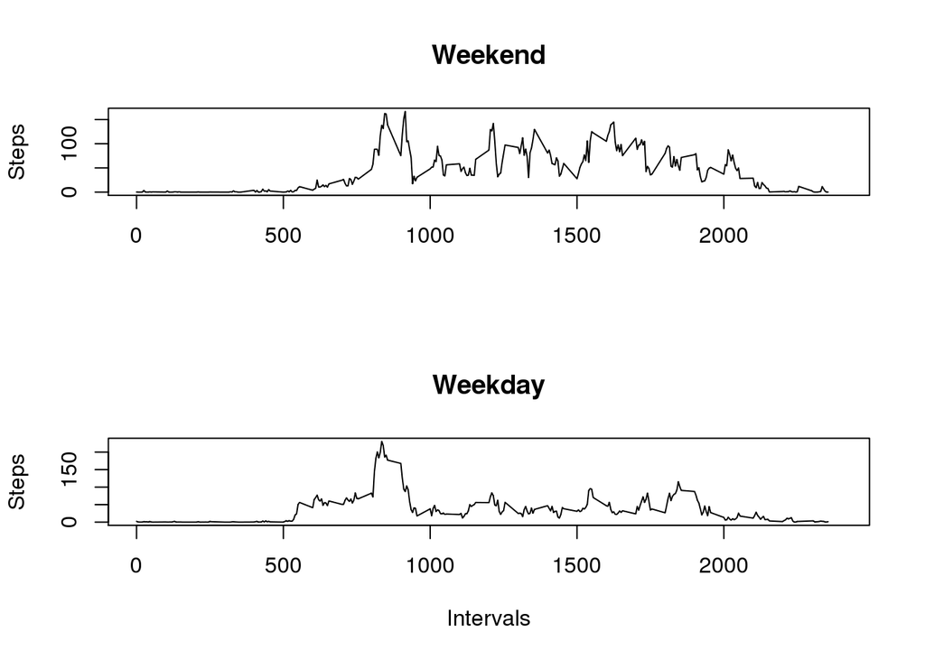

```r
actweekenddf=actdf2[,actdf2[289,]=='weekend']
actweekdaydf=actdf2[,actdf2[289,]=='weekday']

actweekendf=apply(actweekenddf[1:288,],1,function(x)mean(as.numeric(x)))
actweekdayf=apply(actweekdaydf[1:288,],1,function(x)mean(as.numeric(x)))

par(mfrow=c(2,1))
plot(names(actweekendf),actweekendf,type='l',main='Weekend',xlab='',ylab='Steps',xlim=c(0,2400))
plot(names(actweekdayf),actweekdayf,type='l',main='Weekday',xlab='Intervals',ylab='Steps',xlim=c(0,2400))
```

```r
par(mfrow=c(1,1))
```